# Appendix D — Making tables with gt

In this chapter, we will:

1. Learn some basic principles for making better tables.
2. Apply these principles using the `gt` package.

To put these ideas into practice, we’ll use the Palmer penguins data, because I like penguins.

Why `gt`? It has a grammar of tables, like `ggplot2` has for plots, it follows tidyverse conventions, and it can output HTML, LaTeX and RTF. The downside is that there are lots of functions and options to learn, and some older tutorials use arguments that have since been deprecated (for example `vars()`), so check the [function reference](https://gt.rstudio.com/reference/index.html) if code you find online does not run.

For these tutorials we will use the `gt` package. The companion package `gtExtras` adds many more helpers (sparklines, themes, icons) if you want to go further.

To follow along when you run a section of code, look for the output in the **Viewer Pane**.

```r
library(gt)
```

This chapter uses a cleaned version of the penguins data, saved as an R object called `penguins`. Download it with the button below, save it in a `files` folder inside your project, and then load it:

```r
load(here::here("files", "chapter5.RData"))
```

`load()` creates an object called `penguins` in your session, replacing any other `penguins` there, including the one from the palmerpenguins package. It is the same cleaned data as the ggplot appendices use: one row per penguin, with the original `culmen_length_mm` and `culmen_depth_mm` names for the bill measurements, and `species`, `island` and `sex` as text (Which penguins?).

First, tally the penguins. These counts give us a simple dataset for practising table construction.

```r
penguin_counts <- penguins |>
  drop_na(sex) |>
  mutate(year = as.character(year)) |>
  mutate(sex = str_to_lower(sex)) |>
  group_by(species, island, sex, year) |>
  summarise(n = n(), .groups = "drop")

penguin_counts
```

| species | island | sex | year | n |
| --- | --- | --- | --- | --- |
| Adelie | Biscoe | female | 2007 | 5 |
| Adelie | Biscoe | female | 2008 | 9 |
| Adelie | Biscoe | female | 2009 | 8 |
| Adelie | Biscoe | male | 2007 | 5 |
| Adelie | Biscoe | male | 2008 | 9 |
| Adelie | Biscoe | male | 2009 | 8 |
| Adelie | Dream | female | 2007 | 9 |
| Adelie | Dream | female | 2008 | 8 |
| Adelie | Dream | female | 2009 | 10 |
| Adelie | Dream | male | 2007 | 10 |
| Adelie | Dream | male | 2008 | 8 |
| Adelie | Dream | male | 2009 | 10 |
| Adelie | Torgersen | female | 2007 | 8 |
| Adelie | Torgersen | female | 2008 | 8 |
| Adelie | Torgersen | female | 2009 | 8 |
| Adelie | Torgersen | male | 2007 | 7 |
| Adelie | Torgersen | male | 2008 | 8 |
| Adelie | Torgersen | male | 2009 | 8 |
| Chinstrap | Dream | female | 2007 | 13 |
| Chinstrap | Dream | female | 2008 | 9 |
| Chinstrap | Dream | female | 2009 | 12 |
| Chinstrap | Dream | male | 2007 | 13 |
| Chinstrap | Dream | male | 2008 | 9 |
| Chinstrap | Dream | male | 2009 | 12 |
| Gentoo | Biscoe | female | 2007 | 16 |
| Gentoo | Biscoe | female | 2008 | 22 |
| Gentoo | Biscoe | female | 2009 | 20 |
| Gentoo | Biscoe | male | 2007 | 17 |
| Gentoo | Biscoe | male | 2008 | 23 |
| Gentoo | Biscoe | male | 2009 | 21 |

For a real table, you would probably restructure the data to make it easier to read. There’s nothing wrong with the long (i.e., containing many rows) data format, which is excellent for data analysis. However, in a table intended for human readers, rather than machines, you’d likely opt for a wider format.

```r
penguin_counts_wider <- penguin_counts |>
  pivot_wider(
    names_from = c(species, sex),
    values_from = n
  ) |>
  # Make missing numbers (NAs) into zero
  mutate(across(.cols = -(1:2), ~replace_na(., replace = 0))) |>
  arrange(island, year)

penguin_counts_wider
```

| island | year | Adelie_female | Adelie_male | Chinstrap_female | Chinstrap_male | Gentoo_female | Gentoo_male |
| --- | --- | --- | --- | --- | --- | --- | --- |
| Biscoe | 2007 | 5 | 5 | 0 | 0 | 16 | 17 |
| Biscoe | 2008 | 9 | 9 | 0 | 0 | 22 | 23 |
| Biscoe | 2009 | 8 | 8 | 0 | 0 | 20 | 21 |
| Dream | 2007 | 9 | 10 | 13 | 13 | 0 | 0 |
| Dream | 2008 | 8 | 8 | 9 | 9 | 0 | 0 |
| Dream | 2009 | 10 | 10 | 12 | 12 | 0 | 0 |
| Torgersen | 2007 | 8 | 7 | 0 | 0 | 0 | 0 |
| Torgersen | 2008 | 8 | 8 | 0 | 0 | 0 | 0 |
| Torgersen | 2009 | 8 | 8 | 0 | 0 | 0 | 0 |

We will follow six guidelines as we make tables:

1. Avoid vertical lines
2. Use better column names
3. Align columns
4. Use groups instead of repetitive columns
5. Remove missing numbers
6. Add summaries

## D.1 Avoid vertical lines

Vertical lines can make our data look cramped. Fortunately, `gt` follows this principle by default, so all we need to do is supply our dataset, `penguin_counts_wider`, to the `gt()` function.

```r
penguin_counts_wider |>
  gt()
```

| island | year | Adelie_female | Adelie_male | Chinstrap_female | Chinstrap_male | Gentoo_female | Gentoo_male |
| --- | --- | --- | --- | --- | --- | --- | --- |
| Biscoe | 2007 | 5 | 5 | 0 | 0 | 16 | 17 |
| Biscoe | 2008 | 9 | 9 | 0 | 0 | 22 | 23 |
| Biscoe | 2009 | 8 | 8 | 0 | 0 | 20 | 21 |
| Dream | 2007 | 9 | 10 | 13 | 13 | 0 | 0 |
| Dream | 2008 | 8 | 8 | 9 | 9 | 0 | 0 |
| Dream | 2009 | 10 | 10 | 12 | 12 | 0 | 0 |
| Torgersen | 2007 | 8 | 7 | 0 | 0 | 0 | 0 |
| Torgersen | 2008 | 8 | 8 | 0 | 0 | 0 | 0 |
| Torgersen | 2009 | 8 | 8 | 0 | 0 | 0 | 0 |

## D.2 Use better column names and make them stand out

The [`cols_*()` functions](https://gt.rstudio.com/reference/index.html#modifying-columns) allow for modifications of entire columns.

We can control the column labels, cell alignment, column width and placement, and combine multiple columns, with the `cols_*()` functions.

To modify the column names, use the “layer” called `cols_label()`. Like {ggplot2}, {gt} works in layers: to adjust the table, you pass it from one layer to the next with the pipe.

```r
penguin_counts_wider |>
  gt() |>
  cols_label(
    island = 'Island',
    year = 'Year',
    Adelie_female = 'Adelie (female)',
    Adelie_male = 'Adelie (male)',
    Chinstrap_female = 'Chinstrap (female)',
    Chinstrap_male = 'Chinstrap (male)',
    Gentoo_female = 'Gentoo (female)',
    Gentoo_male = 'Gentoo (male)',
  )
```

| Island | Year | Adelie (female) | Adelie (male) | Chinstrap (female) | Chinstrap (male) | Gentoo (female) | Gentoo (male) |
| --- | --- | --- | --- | --- | --- | --- | --- |
| Biscoe | 2007 | 5 | 5 | 0 | 0 | 16 | 17 |
| Biscoe | 2008 | 9 | 9 | 0 | 0 | 22 | 23 |
| Biscoe | 2009 | 8 | 8 | 0 | 0 | 20 | 21 |
| Dream | 2007 | 9 | 10 | 13 | 13 | 0 | 0 |
| Dream | 2008 | 8 | 8 | 9 | 9 | 0 | 0 |
| Dream | 2009 | 10 | 10 | 12 | 12 | 0 | 0 |
| Torgersen | 2007 | 8 | 7 | 0 | 0 | 0 | 0 |
| Torgersen | 2008 | 8 | 8 | 0 | 0 | 0 | 0 |
| Torgersen | 2009 | 8 | 8 | 0 | 0 | 0 | 0 |

However, there is a better way to label these columns. First, we can create what are known as “spanners”, which are merged columns.

We can modify the look of table parts more generally with [`tab_*()` functions](https://gt.rstudio.com/reference/index.html#creating-or-modifying-parts-of-a-table).

Here we generate column spanners with `tab_spanner()` layers, one layer for each spanner. You can also control text formatting of labels with Markdown or HTML syntax. This can be used on any text in a **gt** table. Here I have applied some `md` to put my spanners in **bold**.

```r
penguin_counts_wider |>
  gt() |>
  cols_label(
    island = 'Island',
    year = 'Year',
    Adelie_female = 'Adelie (female)',
    Adelie_male = 'Adelie (male)',
    Chinstrap_female = 'Chinstrap (female)',
    Chinstrap_male = 'Chinstrap (male)',
    Gentoo_female = 'Gentoo (female)',
    Gentoo_male = 'Gentoo (male)',
  ) |>
  # md() function applies markdown styling - we can make text bold
  tab_spanner(
    label = md('**Adelie**'),
    columns = 3:4
  ) |>
  tab_spanner(
    label = md('**Chinstrap**'),
    columns = c('Chinstrap_female', 'Chinstrap_male')
  ) |>
  tab_spanner(
    label =  md('**Gentoo**'),
    columns = contains('Gentoo')
  )
```

| Island | Year | **Adelie** Adelie (female) | **Adelie** Adelie (male) | **Chinstrap** Chinstrap (female) | **Chinstrap** Chinstrap (male) | **Gentoo** Gentoo (female) | **Gentoo** Gentoo (male) |
| --- | --- | --- | --- | --- | --- | --- | --- |
| Biscoe | 2007 | 5 | 5 | 0 | 0 | 16 | 17 |
| Biscoe | 2008 | 9 | 9 | 0 | 0 | 22 | 23 |
| Biscoe | 2009 | 8 | 8 | 0 | 0 | 20 | 21 |
| Dream | 2007 | 9 | 10 | 13 | 13 | 0 | 0 |
| Dream | 2008 | 8 | 8 | 9 | 9 | 0 | 0 |
| Dream | 2009 | 10 | 10 | 12 | 12 | 0 | 0 |
| Torgersen | 2007 | 8 | 7 | 0 | 0 | 0 | 0 |
| Torgersen | 2008 | 8 | 8 | 0 | 0 | 0 | 0 |
| Torgersen | 2009 | 8 | 8 | 0 | 0 | 0 | 0 |

As you can see, tab_spanner() always requires two arguments: label and columns. For the columns argument I have shown you three ways to get the job done:

1. Vector of column numbers
2. Vector of column names
3. tidyselect helpers

Next, we no longer need the species labels in the actual column names, as the spanners already provide that information. To update the column names, we can use a trick that saves a lot of typing.

Create a named vector that maps the original column names, which include species labels, to the desired column names without those labels. For example:

```r
desired_colnames <- colnames(penguin_counts_wider) |>
  str_remove("(Adelie|Gentoo|Chinstrap)_") |>
  str_to_title()

names(desired_colnames) <- names(penguin_counts_wider)
```

Then rename the columns by passing this named vector to the .list argument of `cols_label()`:

```r
penguin_counts_wider |>
    gt() |>
  cols_label(.list = desired_colnames) |>
  # md() function applies markdown styling - we can make text bold
  tab_spanner(
    label = md('**Adelie**'),
    columns = 3:4
  ) |>
  tab_spanner(
    label = md('**Chinstrap**'),
    columns = c('Chinstrap_female', 'Chinstrap_male')
  ) |>
  tab_spanner(
    label =  md('**Gentoo**'),
    columns = contains('Gentoo')
  )
```

| Island | Year | **Adelie** Female | **Adelie** Male | **Chinstrap** Female | **Chinstrap** Male | **Gentoo** Female | **Gentoo** Male |
| --- | --- | --- | --- | --- | --- | --- | --- |
| Biscoe | 2007 | 5 | 5 | 0 | 0 | 16 | 17 |
| Biscoe | 2008 | 9 | 9 | 0 | 0 | 22 | 23 |
| Biscoe | 2009 | 8 | 8 | 0 | 0 | 20 | 21 |
| Dream | 2007 | 9 | 10 | 13 | 13 | 0 | 0 |
| Dream | 2008 | 8 | 8 | 9 | 9 | 0 | 0 |
| Dream | 2009 | 10 | 10 | 12 | 12 | 0 | 0 |
| Torgersen | 2007 | 8 | 7 | 0 | 0 | 0 | 0 |
| Torgersen | 2008 | 8 | 8 | 0 | 0 | 0 | 0 |
| Torgersen | 2009 | 8 | 8 | 0 | 0 | 0 | 0 |

Finally we should add a title to our table. We can do this with `tab_header()`:

```r
penguin_counts_wider |>
    gt() |>
  cols_label(.list = desired_colnames) |>
  # md() function applies markdown styling - we can make text bold
  tab_spanner(
    label = md('**Adelie**'),
    columns = 3:4
  ) |>
  tab_spanner(
    label = md('**Chinstrap**'),
    columns = c('Chinstrap_female', 'Chinstrap_male')
  ) |>
  tab_spanner(
    label =  md('**Gentoo**'),
    columns = contains('Gentoo')
  ) |>
   tab_header(
    title = 'Penguins of the Palmer Archipelago',
    subtitle = 'Data is courtesy of the palmerpenguins R package by Allison Horst'
  )
```

Penguins of the Palmer Archipelago

Data is courtesy of the palmerpenguins R package by Allison Horst

| Island | Year | **Adelie** Female | **Adelie** Male | **Chinstrap** Female | **Chinstrap** Male | **Gentoo** Female | **Gentoo** Male |
| --- | --- | --- | --- | --- | --- | --- | --- |
| Biscoe | 2007 | 5 | 5 | 0 | 0 | 16 | 17 |
| Biscoe | 2008 | 9 | 9 | 0 | 0 | 22 | 23 |
| Biscoe | 2009 | 8 | 8 | 0 | 0 | 20 | 21 |
| Dream | 2007 | 9 | 10 | 13 | 13 | 0 | 0 |
| Dream | 2008 | 8 | 8 | 9 | 9 | 0 | 0 |
| Dream | 2009 | 10 | 10 | 12 | 12 | 0 | 0 |
| Torgersen | 2007 | 8 | 7 | 0 | 0 | 0 | 0 |
| Torgersen | 2008 | 8 | 8 | 0 | 0 | 0 | 0 |
| Torgersen | 2009 | 8 | 8 | 0 | 0 | 0 | 0 |

Because the headers and titles will not change for the rest of this tutorial, we can wrap them in a simple function:

```r
labels_and_title <- function(gt_tbl){
 gt_tbl |>
  tab_spanner(
    label = md('**Adelie**'),
    columns = 3:4
  ) |>
  tab_spanner(
    label = md('**Chinstrap**'),
    columns = c('Chinstrap_female', 'Chinstrap_male')
  ) |>
  tab_spanner(
    label =  md('**Gentoo**'),
    columns = contains('Gentoo')
  ) |>
   tab_header(
    title = 'Penguins of the Palmer Archipelago',
    subtitle = 'Data is courtesy of the palmerpenguins R package by Allison Horst'
  )
}

# This produces the same output
penguin_counts_wider |>
  gt() |>
  cols_label(.list = desired_colnames)  |>
  labels_and_title()
```

Penguins of the Palmer Archipelago

Data is courtesy of the palmerpenguins R package by Allison Horst

| Island | Year | **Adelie** Female | **Adelie** Male | **Chinstrap** Female | **Chinstrap** Male | **Gentoo** Female | **Gentoo** Male |
| --- | --- | --- | --- | --- | --- | --- | --- |
| Biscoe | 2007 | 5 | 5 | 0 | 0 | 16 | 17 |
| Biscoe | 2008 | 9 | 9 | 0 | 0 | 22 | 23 |
| Biscoe | 2009 | 8 | 8 | 0 | 0 | 20 | 21 |
| Dream | 2007 | 9 | 10 | 13 | 13 | 0 | 0 |
| Dream | 2008 | 8 | 8 | 9 | 9 | 0 | 0 |
| Dream | 2009 | 10 | 10 | 12 | 12 | 0 | 0 |
| Torgersen | 2007 | 8 | 7 | 0 | 0 | 0 | 0 |
| Torgersen | 2008 | 8 | 8 | 0 | 0 | 0 | 0 |
| Torgersen | 2009 | 8 | 8 | 0 | 0 | 0 | 0 |

## D.3 Alignment

Align all text within a column using `cols_align()`. Most commonly we left-align text with varying length and right-align numbers.

Here’s why these default alignments make sense:

- Numbers to the Right: Numeric values, such as counts, are usually aligned to the right because this lines up the decimal points and makes numbers easier to compare and calculate with. It also keeps the digits neatly aligned, which matters most with large datasets.
- Text to the Left: Text data, like character vectors, is aligned to the left by default. Text has no decimal points or numeric values to line up, and left-aligning it makes the start of each entry easy to scan, even for long entries.
- Centre Alignment for Factors: Factors (categorical data) are centred by default, as a compromise between left and right alignment. A factor’s entries are text, but they represent categories and are often used for grouping or sorting. Centring the labels makes each category easy to pick out.

These defaults follow well-established conventions in table formatting and help readers interpret tabular data quickly.

In our data both `island` and `year` are character columns, so `gt` left-aligns them by default (a factor column would be centred). We could recode these in our data, or we can set the alignment explicitly with the `cols_align()` layer. Here we right-align `year` and make sure `island` is left-aligned:

```r
penguin_counts_wider |>
  gt() |>
  cols_label(.list = desired_colnames) |>
  labels_and_title()  |>
  cols_align(align = 'right', columns = 'year') |>
  cols_align(
    align = 'left',
    columns = island
  )
```

Penguins of the Palmer Archipelago

Data is courtesy of the palmerpenguins R package by Allison Horst

| Island | Year | **Adelie** Female | **Adelie** Male | **Chinstrap** Female | **Chinstrap** Male | **Gentoo** Female | **Gentoo** Male |
| --- | --- | --- | --- | --- | --- | --- | --- |
| Biscoe | 2007 | 5 | 5 | 0 | 0 | 16 | 17 |
| Biscoe | 2008 | 9 | 9 | 0 | 0 | 22 | 23 |
| Biscoe | 2009 | 8 | 8 | 0 | 0 | 20 | 21 |
| Dream | 2007 | 9 | 10 | 13 | 13 | 0 | 0 |
| Dream | 2008 | 8 | 8 | 9 | 9 | 0 | 0 |
| Dream | 2009 | 10 | 10 | 12 | 12 | 0 | 0 |
| Torgersen | 2007 | 8 | 7 | 0 | 0 | 0 | 0 |
| Torgersen | 2008 | 8 | 8 | 0 | 0 | 0 | 0 |
| Torgersen | 2009 | 8 | 8 | 0 | 0 | 0 | 0 |

## D.4 Move columns around

Move columns to the start or end or wherever you like with `cols_move_*()` functions:

```r
penguin_counts_wider |>
  gt() |>
  cols_label(.list = desired_colnames) |>
  labels_and_title()  |>
  cols_align(align = 'right', columns = 'year') |>
  cols_align(
    align = 'left',
    columns = island
  ) |>
  cols_move_to_start(columns = year)
```

Penguins of the Palmer Archipelago

Data is courtesy of the palmerpenguins R package by Allison Horst

| Year | Island | **Adelie** Female | **Adelie** Male | **Chinstrap** Female | **Chinstrap** Male | **Gentoo** Female | **Gentoo** Male |
| --- | --- | --- | --- | --- | --- | --- | --- |
| 2007 | Biscoe | 5 | 5 | 0 | 0 | 16 | 17 |
| 2008 | Biscoe | 9 | 9 | 0 | 0 | 22 | 23 |
| 2009 | Biscoe | 8 | 8 | 0 | 0 | 20 | 21 |
| 2007 | Dream | 9 | 10 | 13 | 13 | 0 | 0 |
| 2008 | Dream | 8 | 8 | 9 | 9 | 0 | 0 |
| 2009 | Dream | 10 | 10 | 12 | 12 | 0 | 0 |
| 2007 | Torgersen | 8 | 7 | 0 | 0 | 0 | 0 |
| 2008 | Torgersen | 8 | 8 | 0 | 0 | 0 | 0 |
| 2009 | Torgersen | 8 | 8 | 0 | 0 | 0 | 0 |

## D.5 Avoid repetitive information

Removing repetitive columns and using extra rows to group the data makes a table easier to read. In `gt` this is straightforward. Here’s how to do it with two arguments to `gt()`: `groupname_col` says which column to group the rows by, and `rowname_col` says which column to use as the row labels:

```r
penguin_counts_wider |>
  mutate(
    island = as.character(island),
    year = as.numeric(year)
  ) |>
  gt(groupname_col = 'island', rowname_col = 'year') |>
  cols_label(.list = desired_colnames) |>
  labels_and_title()
```

Penguins of the Palmer Archipelago

Data is courtesy of the palmerpenguins R package by Allison Horst

|  | **Adelie** Female | **Adelie** Male | **Chinstrap** Female | **Chinstrap** Male | **Gentoo** Female | **Gentoo** Male |
| --- | --- | --- | --- | --- | --- | --- |
| Biscoe |  |  |  |  |  |  |
| 2007 | 5 | 5 | 0 | 0 | 16 | 17 |
| 2008 | 9 | 9 | 0 | 0 | 22 | 23 |
| 2009 | 8 | 8 | 0 | 0 | 20 | 21 |
| Dream |  |  |  |  |  |  |
| 2007 | 9 | 10 | 13 | 13 | 0 | 0 |
| 2008 | 8 | 8 | 9 | 9 | 0 | 0 |
| 2009 | 10 | 10 | 12 | 12 | 0 | 0 |
| Torgersen |  |  |  |  |  |  |
| 2007 | 8 | 7 | 0 | 0 | 0 | 0 |
| 2008 | 8 | 8 | 0 | 0 | 0 | 0 |
| 2009 | 8 | 8 | 0 | 0 | 0 | 0 |

But an island label could be nice. The easiest way to add that to the group names is via string manipulation before `gt()` is called.

```r
penguin_counts_wider |>
  mutate(
    island = as.character(island),
    year = as.numeric(year),
    island = paste0('Island: ', island)
  ) |>
  gt(groupname_col = 'island', rowname_col = 'year') |>
  cols_label(.list = desired_colnames) |>
  labels_and_title()
```

Penguins of the Palmer Archipelago

Data is courtesy of the palmerpenguins R package by Allison Horst

|  | **Adelie** Female | **Adelie** Male | **Chinstrap** Female | **Chinstrap** Male | **Gentoo** Female | **Gentoo** Male |
| --- | --- | --- | --- | --- | --- | --- |
| Island: Biscoe |  |  |  |  |  |  |
| 2007 | 5 | 5 | 0 | 0 | 16 | 17 |
| 2008 | 9 | 9 | 0 | 0 | 22 | 23 |
| 2009 | 8 | 8 | 0 | 0 | 20 | 21 |
| Island: Dream |  |  |  |  |  |  |
| 2007 | 9 | 10 | 13 | 13 | 0 | 0 |
| 2008 | 8 | 8 | 9 | 9 | 0 | 0 |
| 2009 | 10 | 10 | 12 | 12 | 0 | 0 |
| Island: Torgersen |  |  |  |  |  |  |
| 2007 | 8 | 7 | 0 | 0 | 0 | 0 |
| 2008 | 8 | 8 | 0 | 0 | 0 | 0 |
| 2009 | 8 | 8 | 0 | 0 | 0 | 0 |

## D.6 Remove missing numbers

If we want to remove zeroes from our table, we could use `dplyr` functions:

```r
penguin_counts_wider |>
    mutate(
        island = as.character(island),
        year = as.numeric(year),
        island = paste0('Island: ', island)
    ) |>
    mutate(across(.cols = where(is.integer), .fns = ~ifelse(.x <= 0, "-", as.character(.) ))) |>
  gt(groupname_col = 'island', rowname_col = 'year') |>
  cols_label(.list = desired_colnames) |>
  labels_and_title()
```

Penguins of the Palmer Archipelago

Data is courtesy of the palmerpenguins R package by Allison Horst

|  | **Adelie** Female | **Adelie** Male | **Chinstrap** Female | **Chinstrap** Male | **Gentoo** Female | **Gentoo** Male |
| --- | --- | --- | --- | --- | --- | --- |
| Island: Biscoe |  |  |  |  |  |  |
| 2007 | 5 | 5 | - | - | 16 | 17 |
| 2008 | 9 | 9 | - | - | 22 | 23 |
| 2009 | 8 | 8 | - | - | 20 | 21 |
| Island: Dream |  |  |  |  |  |  |
| 2007 | 9 | 10 | 13 | 13 | - | - |
| 2008 | 8 | 8 | 9 | 9 | - | - |
| 2009 | 10 | 10 | 12 | 12 | - | - |
| Island: Torgersen |  |  |  |  |  |  |
| 2007 | 8 | 7 | - | - | - | - |
| 2008 | 8 | 8 | - | - | - | - |
| 2009 | 8 | 8 | - | - | - | - |

Or we can accomplish the same thing by adding a `sub_zero()` layer:

```r
penguin_counts_wider |>
  mutate(
    island = as.character(island),
    year = as.numeric(year),
    island = paste0('Island: ', island)
  ) |>
  gt(groupname_col = 'island', rowname_col = 'year') |>
  cols_label(.list = desired_colnames) |>
  labels_and_title()  |>
  sub_zero(zero_text = '-')
```

Penguins of the Palmer Archipelago

Data is courtesy of the palmerpenguins R package by Allison Horst

|  | **Adelie** Female | **Adelie** Male | **Chinstrap** Female | **Chinstrap** Male | **Gentoo** Female | **Gentoo** Male |
| --- | --- | --- | --- | --- | --- | --- |
| Island: Biscoe |  |  |  |  |  |  |
| 2007 | 5 | 5 | - | - | 16 | 17 |
| 2008 | 9 | 9 | - | - | 22 | 23 |
| 2009 | 8 | 8 | - | - | 20 | 21 |
| Island: Dream |  |  |  |  |  |  |
| 2007 | 9 | 10 | 13 | 13 | - | - |
| 2008 | 8 | 8 | 9 | 9 | - | - |
| 2009 | 10 | 10 | 12 | 12 | - | - |
| Island: Torgersen |  |  |  |  |  |  |
| 2007 | 8 | 7 | - | - | - | - |
| 2008 | 8 | 8 | - | - | - | - |
| 2009 | 8 | 8 | - | - | - | - |

## D.7 Add summaries

If needed, we can also add summaries to the table with `summary_rows()`. Sub-zero doesn’t seem to work in the summaries, so we need a workaround:

```r
penguin_counts_wider |>
  mutate(
    island = as.character(island),
    year = as.numeric(year),
    island = paste0('Island: ', island)
  ) |>
  gt(groupname_col = 'island', rowname_col = 'year') |>
  cols_label(.list = desired_colnames) |>
  labels_and_title()  |>
  sub_zero(zero_text = '-')|>
   summary_rows(
    groups = everything(),
   fns = list(
      "Mean" = ~na_if(mean(., na.rm = TRUE), 0),
      "Total" = ~na_if(sum(., na.rm = TRUE), 0)
    ),
    fmt = list(~fmt_number(., decimals = 0)),
    missing_text = "-")
```

Penguins of the Palmer Archipelago

Data is courtesy of the palmerpenguins R package by Allison Horst

|  | **Adelie** Female | **Adelie** Male | **Chinstrap** Female | **Chinstrap** Male | **Gentoo** Female | **Gentoo** Male |
| --- | --- | --- | --- | --- | --- | --- |
| Island: Biscoe |  |  |  |  |  |  |
| 2007 | 5 | 5 | - | - | 16 | 17 |
| 2008 | 9 | 9 | - | - | 22 | 23 |
| 2009 | 8 | 8 | - | - | 20 | 21 |
| Mean | 7 | 7 | - | - | 19 | 20 |
| Total | 22 | 22 | - | - | 58 | 61 |
| Island: Dream |  |  |  |  |  |  |
| 2007 | 9 | 10 | 13 | 13 | - | - |
| 2008 | 8 | 8 | 9 | 9 | - | - |
| 2009 | 10 | 10 | 12 | 12 | - | - |
| Mean | 9 | 9 | 11 | 11 | - | - |
| Total | 27 | 28 | 34 | 34 | - | - |
| Island: Torgersen |  |  |  |  |  |  |
| 2007 | 8 | 7 | - | - | - | - |
| 2008 | 8 | 8 | - | - | - | - |
| 2009 | 8 | 8 | - | - | - | - |
| Mean | 8 | 8 | - | - | - | - |
| Total | 24 | 23 | - | - | - | - |

## D.8 Stylise

With the summaries added, the table has grown longer. We can make it more compact by decreasing the row heights.

To do this, set `data_row.padding` to 2 pixels with the `tab_options()` function, which is the main layer for styling the table. There are similar padding options for `summary_row` and `row_group`. While we’re at it, we can also apply a predefined theme with `opt_stylize()`.

```r
penguin_counts_wider |>
  mutate(
    island = as.character(island),
    year = as.numeric(year),
    island = paste0('Island: ', island)
  ) |>
  gt(groupname_col = 'island', rowname_col = 'year') |>
  cols_label(.list = desired_colnames) |>
  labels_and_title()  |>
  sub_zero(zero_text = '-')|>
   summary_rows(
    groups = everything(),
   fns = list(
      "Mean" = ~na_if(mean(., na.rm = TRUE), 0),
      "Total" = ~na_if(sum(., na.rm = TRUE), 0)
    ),
    fmt = list(~fmt_number(., decimals = 0)),
    missing_text = "-") |>
    tab_options(
    data_row.padding = px(2),
    summary_row.padding = px(3), # A bit more padding for summaries
    row_group.padding = px(4)    # And even more for our groups
  ) |>
  opt_stylize(style = 6, color = 'gray')
```

Penguins of the Palmer Archipelago

Data is courtesy of the palmerpenguins R package by Allison Horst

|  | **Adelie** Female | **Adelie** Male | **Chinstrap** Female | **Chinstrap** Male | **Gentoo** Female | **Gentoo** Male |
| --- | --- | --- | --- | --- | --- | --- |
| Island: Biscoe |  |  |  |  |  |  |
| 2007 | 5 | 5 | - | - | 16 | 17 |
| 2008 | 9 | 9 | - | - | 22 | 23 |
| 2009 | 8 | 8 | - | - | 20 | 21 |
| Mean | 7 | 7 | - | - | 19 | 20 |
| Total | 22 | 22 | - | - | 58 | 61 |
| Island: Dream |  |  |  |  |  |  |
| 2007 | 9 | 10 | 13 | 13 | - | - |
| 2008 | 8 | 8 | 9 | 9 | - | - |
| 2009 | 10 | 10 | 12 | 12 | - | - |
| Mean | 9 | 9 | 11 | 11 | - | - |
| Total | 27 | 28 | 34 | 34 | - | - |
| Island: Torgersen |  |  |  |  |  |  |
| 2007 | 8 | 7 | - | - | - | - |
| 2008 | 8 | 8 | - | - | - | - |
| 2009 | 8 | 8 | - | - | - | - |
| Mean | 8 | 8 | - | - | - | - |
| Total | 24 | 23 | - | - | - | - |

## D.9 Use appropriate colour

So far, our table hasn’t used any colour. We’ll add some now to highlight the largest values.

```r
penguin_counts_wider |>
  mutate(
    island = as.character(island),
    year = as.numeric(year),
    island = paste0('Island: ', island)
  ) |>
  gt(groupname_col = 'island', rowname_col = 'year') |>
  cols_label(.list = desired_colnames) |>
  labels_and_title()  |>
  sub_zero(zero_text = '-')|>
   summary_rows(
    groups = everything(),
   fns = list(
      "Mean" = ~na_if(mean(., na.rm = TRUE), 0),
      "Total" = ~na_if(sum(., na.rm = TRUE), 0)
    ),
    fmt = list(~fmt_number(., decimals = 0)),
    missing_text = "-") |>
    tab_options(
    data_row.padding = px(2),
    summary_row.padding = px(3), # A bit more padding for summaries
    row_group.padding = px(4)    # And even more for our groups
   )|>
    tab_style(style = cell_text(color = "orange",
                              weight = "bold"),
            locations = cells_body(
              columns = 3,
             rows = which(penguin_counts_wider[,3] == max(penguin_counts_wider[,3])))
            )
```

Penguins of the Palmer Archipelago

Data is courtesy of the palmerpenguins R package by Allison Horst

|  | **Adelie** Female | **Adelie** Male | **Chinstrap** Female | **Chinstrap** Male | **Gentoo** Female | **Gentoo** Male |
| --- | --- | --- | --- | --- | --- | --- |
| Island: Biscoe |  |  |  |  |  |  |
| 2007 | 5 | 5 | - | - | 16 | 17 |
| 2008 | 9 | 9 | - | - | 22 | 23 |
| 2009 | 8 | 8 | - | - | 20 | 21 |
| Mean | 7 | 7 | - | - | 19 | 20 |
| Total | 22 | 22 | - | - | 58 | 61 |
| Island: Dream |  |  |  |  |  |  |
| 2007 | 9 | 10 | 13 | 13 | - | - |
| 2008 | 8 | 8 | 9 | 9 | - | - |
| 2009 | 10 | 10 | 12 | 12 | - | - |
| Mean | 9 | 9 | 11 | 11 | - | - |
| Total | 27 | 28 | 34 | 34 | - | - |
| Island: Torgersen |  |  |  |  |  |  |
| 2007 | 8 | 7 | - | - | - | - |
| 2008 | 8 | 8 | - | - | - | - |
| 2009 | 8 | 8 | - | - | - | - |
| Mean | 8 | 8 | - | - | - | - |
| Total | 24 | 23 | - | - | - | - |

If we repeat this code for each column, we get the result shown below:

Penguins of the Palmer Archipelago

Data is courtesy of the palmerpenguins R package by Allison Horst

|  | **Adelie** Female | **Adelie** Male | **Chinstrap** Female | **Chinstrap** Male | **Gentoo** Female | **Gentoo** Male |
| --- | --- | --- | --- | --- | --- | --- |
| Island: Biscoe |  |  |  |  |  |  |
| 2007 | 5 | 5 | - | - | 16 | 17 |
| 2008 | 9 | 9 | - | - | 22 | 23 |
| 2009 | 8 | 8 | - | - | 20 | 21 |
| Mean | 7 | 7 | - | - | 19 | 20 |
| Total | 22 | 22 | - | - | 58 | 61 |
| Island: Dream |  |  |  |  |  |  |
| 2007 | 9 | 10 | 13 | 13 | - | - |
| 2008 | 8 | 8 | 9 | 9 | - | - |
| 2009 | 10 | 10 | 12 | 12 | - | - |
| Mean | 9 | 9 | 11 | 11 | - | - |
| Total | 27 | 28 | 34 | 34 | - | - |
| Island: Torgersen |  |  |  |  |  |  |
| 2007 | 8 | 7 | - | - | - | - |
| 2008 | 8 | 8 | - | - | - | - |
| 2009 | 8 | 8 | - | - | - | - |
| Mean | 8 | 8 | - | - | - | - |
| Total | 24 | 23 | - | - | - | - |

## D.10 Heatmap

We can colour the cells as a heatmap to show the differences more clearly. This needs a colour palette and conditional colouring with `data_color()`:

```r
penguin_counts_wider |>
  mutate(
    island = as.character(island),
    year = as.numeric(year),
    island = paste0('Island: ', island)
  ) |>
  gt(groupname_col = 'island', rowname_col = 'year') |>
  cols_label(.list = desired_colnames) |>
  labels_and_title()  |>
  sub_zero(zero_text = '-')|>
   summary_rows(
    groups = everything(),
   fns = list(
      "Mean" = ~na_if(mean(., na.rm = TRUE), 0),
      "Total" = ~na_if(sum(., na.rm = TRUE), 0)
    ),
    fmt = list(~fmt_number(., decimals = 0)),
    missing_text = "-") |>
    tab_options(
    data_row.padding = px(2),
    summary_row.padding = px(3), # A bit more padding for summaries
    row_group.padding = px(4)    # And even more for our groups
   )|>
data_color(palette = c("#FEF0D9", "#990000"), domain = c(0,30))
```

Penguins of the Palmer Archipelago

Data is courtesy of the palmerpenguins R package by Allison Horst

|  | **Adelie** Female | **Adelie** Male | **Chinstrap** Female | **Chinstrap** Male | **Gentoo** Female | **Gentoo** Male |
| --- | --- | --- | --- | --- | --- | --- |
| Island: Biscoe |  |  |  |  |  |  |
| 2007 | 5 | 5 | - | - | 16 | 17 |
| 2008 | 9 | 9 | - | - | 22 | 23 |
| 2009 | 8 | 8 | - | - | 20 | 21 |
| Mean | 7 | 7 | - | - | 19 | 20 |
| Total | 22 | 22 | - | - | 58 | 61 |
| Island: Dream |  |  |  |  |  |  |
| 2007 | 9 | 10 | 13 | 13 | - | - |
| 2008 | 8 | 8 | 9 | 9 | - | - |
| 2009 | 10 | 10 | 12 | 12 | - | - |
| Mean | 9 | 9 | 11 | 11 | - | - |
| Total | 27 | 28 | 34 | 34 | - | - |
| Island: Torgersen |  |  |  |  |  |  |
| 2007 | 8 | 7 | - | - | - | - |
| 2008 | 8 | 8 | - | - | - | - |
| 2009 | 8 | 8 | - | - | - | - |
| Mean | 8 | 8 | - | - | - | - |
| Total | 24 | 23 | - | - | - | - |

## D.11 Data visualisations

Next, we’re going to add plots to a `gt` table.

You can add any ggplot you want to your table. For example, we could look at our penguins again and build a table about their weight and its distribution (visualised with a violin plot).

Start by computing the numeric values.

```r
filtered_penguins <- penguins |>
    filter(!is.na(sex))

penguin_weights <- filtered_penguins |>
  group_by(species) |>
  summarise(
    Min = min(body_mass_g),
    Mean = mean(body_mass_g) |> round(digits = 2),
    Max = max(body_mass_g)
  ) |>
  mutate(species = as.character(species)) |>
  rename(Species = species)

penguin_weights |>
  gt() |>
  tab_spanner(
    label = 'Penguin\'s Weight',
    columns = -Species
  )
```

| Species | Penguin's Weight Min | Penguin's Weight Mean | Penguin's Weight Max |
| --- | --- | --- | --- |
| Adelie | 2850 | 3706.16 | 4775 |
| Chinstrap | 2700 | 3733.09 | 4800 |
| Gentoo | 3950 | 5092.44 | 6300 |

A violin plot for one species

Next write a function `plot_violin_species(my_species)` that takes a penguin species and creates one violin plot of `body_mass_g` from `filtered_penguins`.

```r
plot_violin_species <- function(my_species) {
  full_range <- filtered_penguins |>
    pull(body_mass_g) |>
    range()

  filtered_penguins |>
    filter(species == my_species) |>
    ggplot(aes(x = body_mass_g, y = species)) +
    geom_violin(fill = 'dodgerblue4') +
    theme_minimal() +
    scale_y_discrete(breaks = NULL) +
    scale_x_continuous(breaks = NULL) +
    labs(x = NULL, y = NULL) +
    coord_cartesian(xlim = full_range)
}
plot_violin_species("Adelie")
```

[figure not shown]

Notice that I have set the coordinate system of the plot to the full range of the data (regardless of the species). Without this, the three plots would not share a common x-axis.

Now that we have a function that creates the plots, we can apply it to our table. For this to work, we need an additional column that we can target. So we use `mutate()` to add a new column, then `text_transform()` to turn this column into images, and finally supply the `fn` argument with our function, iterated over each species with `map()`.

Species

Penguin's Weight

Min

Mean

Max

Distribution

Adelie

2850

3706.16

4775

[figure not shown]

Chinstrap

2700

3733.09

4800

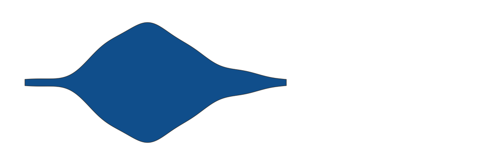

Gentoo

3950

5092.44

6300

[figure not shown]

```r
penguin_weights |>
  mutate(Distribution = Species) |>
  gt() |>
  tab_spanner(
    label = 'Penguin\'s Weight',
    columns = -Species
  ) |>
  text_transform(
    locations = cells_body(columns = 'Distribution'),
    fn = function(column) {
      map(column, plot_violin_species) |>
        ggplot_image(height = px(50), aspect_ratio = 3)
    }
  )
```

## D.12 Conclusion

Many of the tweaks we made to our table are quite subtle. Changes like avoiding vertical lines, bolding header text, right-aligning numeric values, and adjusting the level of precision can often go unnoticed, but if you skip them, your table will be far less effective. Our final product isn’t flashy, but it does communicate clearly.

We used the gt package to make our high-quality table, and as we’ve repeatedly seen, this package has good defaults built in. Often, you don’t need to change much in your code to make effective tables. But whichever package you use, give tables as much thought as any other kind of data visualisation.

You can put these tables straight into a Quarto document (see the Quarto block on Day 3), where they render as part of your report.

## D.13 Reading

Consult the following resources to learn about table design principles and how to make high-quality tables with the gt package:

[“gt package intro”](https://gt.rstudio.com/articles/gt.html)

“Ten Guidelines for Better Tables” by Jon Schwabish (Journal of Benefit-Cost Analysis, 2020), https://doi.org/10.1017/bca.2020.11

“10+ Guidelines for Better Tables in R” by Tom Mock (2020), https://themockup.blog/posts/2020-09-04-10-table-rules-in-r/